# Tutorial — Construção de Gráficos no R

## 8.1 6.1. Comparações Avançadas por Grupos (Mesma Escala e Facetas)

Quando trabalhamos com múltiplos grupos (como dados de Meninas e Meninos), podemos comparecer as distribuições mapeando propriedades estéticas no mesmo gráfico ou separando-os rigidamente por painéis (facetas). O `ggplot2` garante automaticamente que as escalas de X e Y fiquem perfeitamente idênticas para evitar distorções na comparação visual.

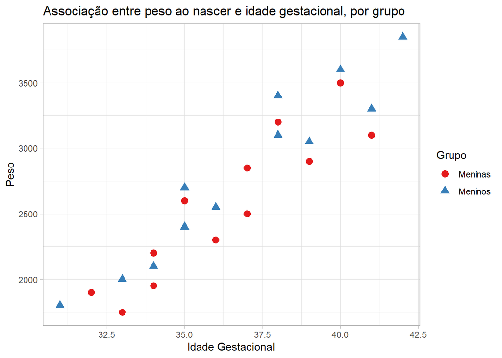

```r
# Base de dados expandida incluindo Meninos
df_completo <- data.frame(
  x = c(32, 33, 34, 34, 35, 36, 37, 37, 38, 39, 40, 41,  # Meninas
        31, 33, 34, 35, 35, 36, 38, 38, 39, 40, 41, 42), # Meninos
  y = c(1900, 1750, 2200, 1950, 2600, 2300, 2850, 2500, 3200, 2900, 3500, 3100,
        1800, 2000, 2100, 2400, 2700, 2550, 3100, 3400, 3050, 3600, 3300, 3850),
  sexo = factor(rep(c("Meninas", "Meninos"), each = 12))
)

# 1. Ambos os grupos no MESMO gráfico (Cores e Símbolos diferentes)
ggplot(df_completo, aes(x = x, y = y, color = sexo, shape = sexo)) +
  geom_point(size = 3) +
  scale_color_manual(values = c("Meninas" = "#e41a1c", "Meninos" = "#377eb8")) +
  scale_shape_manual(values = c("Meninas" = 16, "Meninos" = 17)) +
  labs(title = "Associação entre peso ao nascer e idade gestacional, por grupo", x = "Idade Gestacional", y = "Peso", color = "Grupo", shape = "Grupo") +
  theme_light()
```

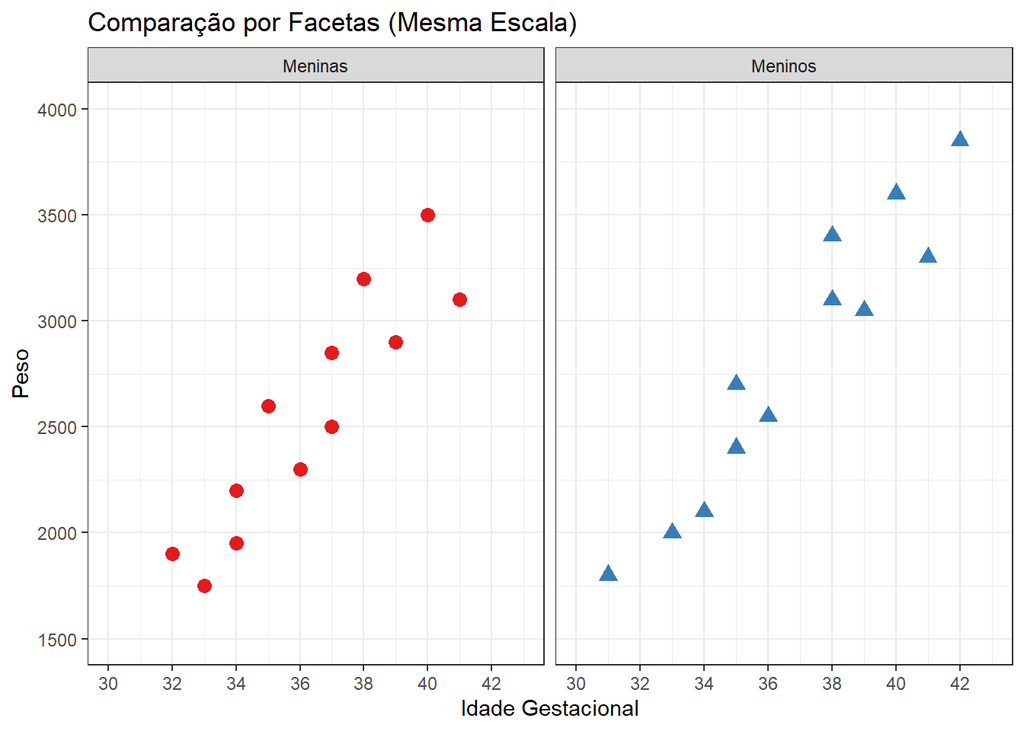

```r
# 2. Painéis Separados por Facetas (Rígida igualdade de escala automática)
ggplot(df_completo, aes(x = x, y = y, color = sexo, shape = sexo)) +
  geom_point(size = 3, show.legend = FALSE) +
  facet_wrap(~ sexo) +
  scale_color_manual(values = c("Meninas" = "#e41a1c", "Meninos" = "#377eb8")) +
  scale_shape_manual(values = c("Meninas" = 16, "Meninos" = 17)) +
  scale_x_continuous(limits = c(30, 43), breaks = seq(30, 42, by = 2)) +
  scale_y_continuous(limits = c(1500, 4000), breaks = seq(1500, 4000, by = 500)) +
  labs(title = "Comparação por Facetas (Mesma Escala)", x = "Idade Gestacional", y = "Peso") +
  theme_bw()
```

# 9 7. Gráficos para Variáveis Categóricas (Barras)

Diferente do R clássico, você não precisa calcular as tabelas de frequência manualmente usando `table()`. O `geom_bar()` faz a contagem automática por trás dos panos.

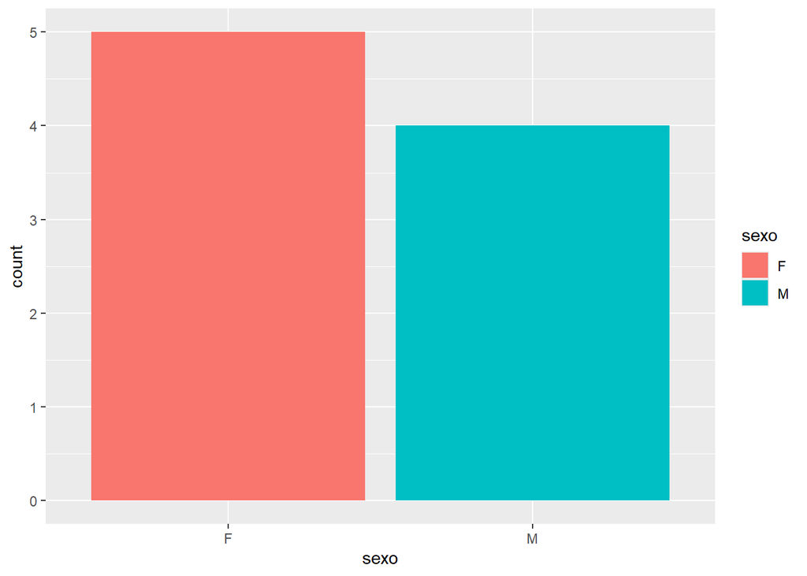

```r
df_sociodemo <- data.frame(
  sexo = factor(c("F", "M", "F", "F", "M", "M", "F", "M", "F")),
  estado_civil = factor(c("solteiro", "solteiro", "casado", "casado", "solteiro", "casado", "solteiro", "casado", "solteiro"))
)

# Gráfico de contagem simples com preenchimento (fill) mapeado ao sexo
ggplot(df_sociodemo, aes(x = sexo, fill = sexo)) +
  geom_bar()
```

## 9.1 Distribuição Conjunta e Condicional

Controlamos a disposição das barras de duas variáveis categóricas usando o argumento `position`:

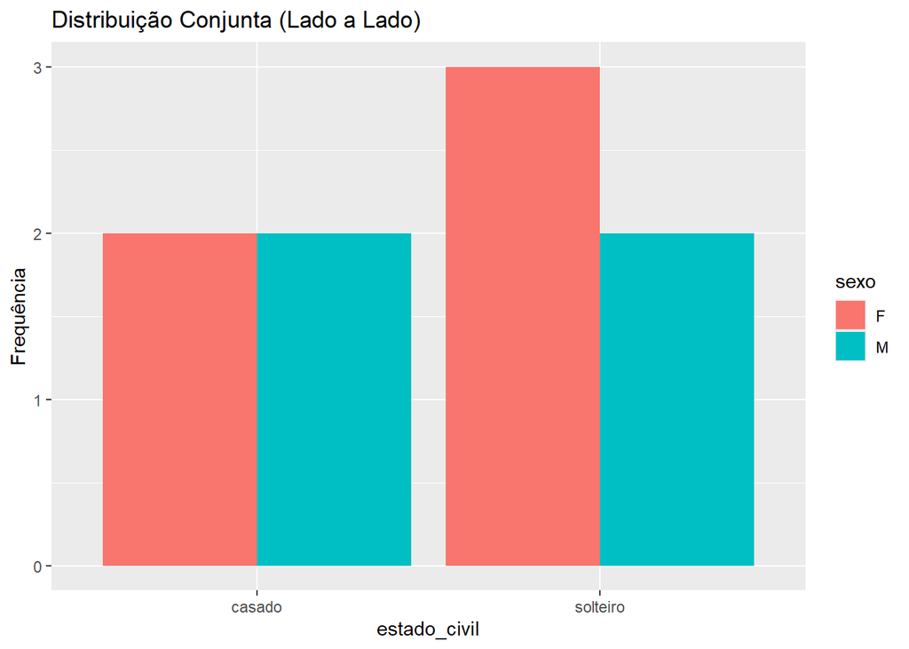

```r
# Barras lado a lado (Equivalente ao beside = TRUE)
ggplot(df_sociodemo, aes(x = estado_civil, fill = sexo)) +
  geom_bar(position = "dodge") +
  labs(title = "Distribuição Conjunta (Lado a Lado)", y = "Frequência")
```

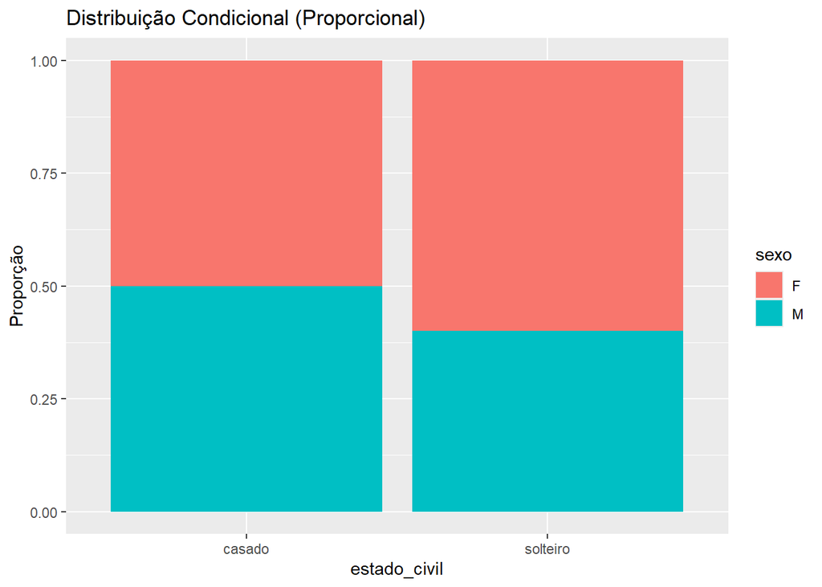

```r
# Distribuição Condicional Percentual (Empilhado 100%)
ggplot(df_sociodemo, aes(x = estado_civil, fill = sexo)) +
  geom_bar(position = "fill") +
  labs(title = "Distribuição Condicional (Proporcional)", y = "Proporção")
```

# 10 8. Distribuições Quantitativas: Histograma e Boxplot

## 10.1 Histograma

Controlamos o número de intervalos usando o argumento `bins` diretamente na geometria.

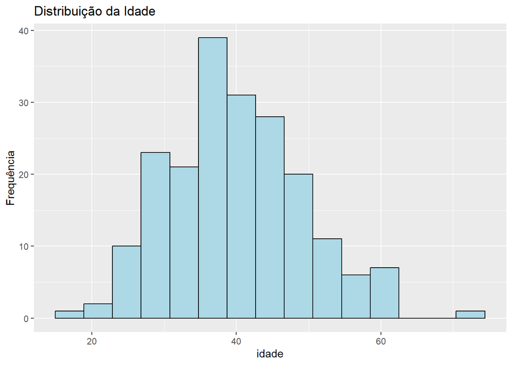

```r
set.seed(123)
df_amostra <- data.frame(
  idade = rnorm(200, mean = 40, sd = 10),
  grupo = sample(c("A", "B"), 200, replace = TRUE)
)

ggplot(df_amostra, aes(x = idade)) +
  geom_histogram(bins = 15, fill = "lightblue", color = "black") +
  labs(title = "Distribuição da Idade", y = "Frequência")
```

## 10.2 Boxplot Combinado com Pontos Dispersos

Para evitar ocultar dados e enriquecer a visualização, podemos sobrepor o boxplot com um `geom_jitter()` (que espalha os pontos horizontalmente para não se sobreporem).

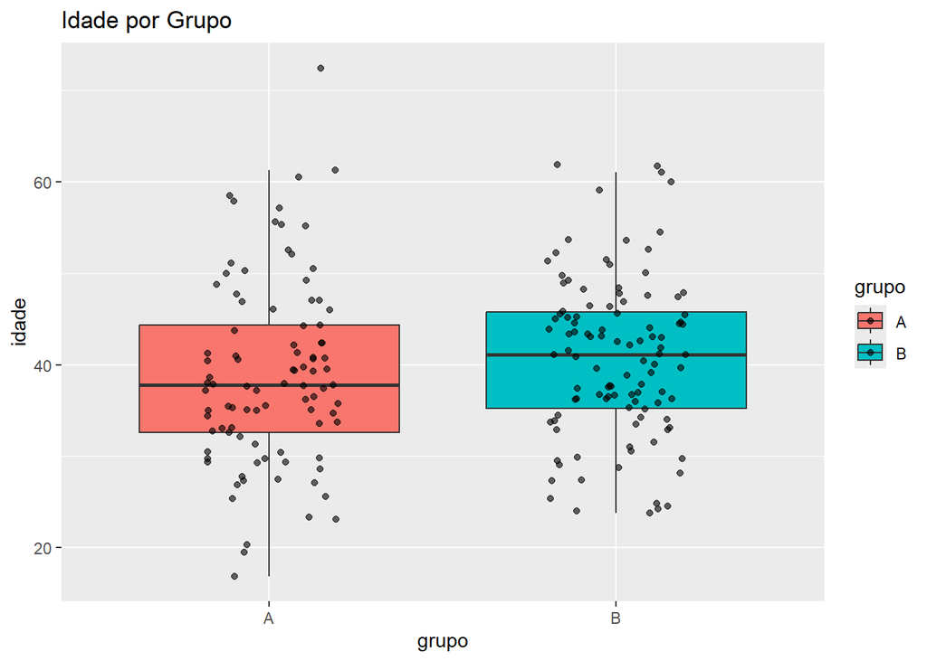

```r
ggplot(df_amostra, aes(x = grupo, y = idade, fill = grupo)) +
  geom_boxplot(outlier.shape = NA) +
  geom_jitter(width = 0.2, alpha = 0.6) +
  labs(title = "Idade por Grupo")
```

## 10.3 8.1. Organização Avançada de Layouts: Os pacotes `patchwork` e `ggExtra`

Quando precisamos combinar múltiplos subgráficos em uma mesma figura impressa, a filosofia de camadas do `ggplot2` exige extensões especializadas para manter o alinhamento perfeito dos eixos.

### 10.3.1 Possibilidade 1: Combinação e Empilhamento Geral com `patchwork`

O pacote `patchwork` permite usar operadores aritméticos simples para combinar plots totalmente independentes.

- O operador **`+`** ou **`|`** posiciona os gráficos lado a lado (colunas).
- O operador **`/`** empilha os gráficos verticalmente (linhas).
- A função **`plot_layout()`** ajusta as proporções e alturas/larguras relativas.

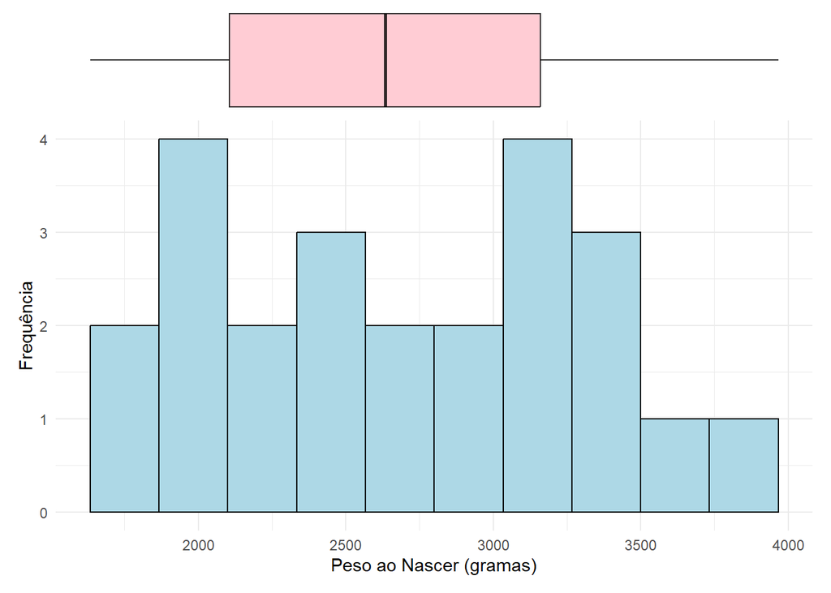

```r
library(patchwork)

# Gráfico A: Boxplot Horizontal isolado
p1 <- ggplot(df_completo, aes(x = y)) +
  geom_boxplot(fill = "lightpink", alpha = 0.7) +
  theme_void()

# Gráfico B: Histograma correspondente
p2 <- ggplot(df_completo, aes(x = y)) +
  geom_histogram(bins = 10, fill = "lightblue", color = "black") +
  labs(x = "Peso ao Nascer (gramas)", y = "Frequência") +
  theme_minimal()

# Executando a Possibilidade 1A: Empilhamento Proporcional (Boxplot 20% do tamanho)
p1 / p2 + plot_layout(heights = c(0.2, 0.8))
```

Podemos também criar matrizes de gráficos combinando os operadores lado a lado e de empilhamento:

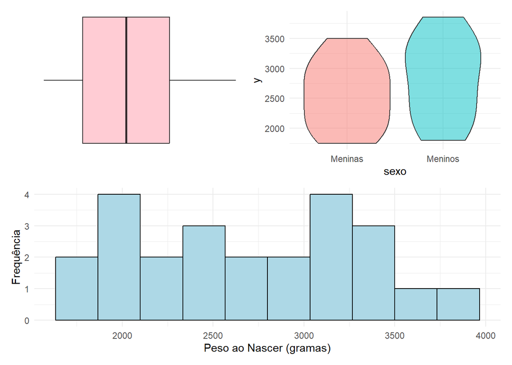

```r
# Criando um terceiro gráfico de exemplo
p3 <- ggplot(df_completo, aes(x = sexo, y = y, fill = sexo)) +
  geom_violin(alpha = 0.5) + theme_minimal() + theme(legend.position = "none")

# Executando a Possibilidade 1B: Layout Customizado Complexo (Dois no topo, um esticado embaixo)
(p1 | p3) / p2
```

### 10.3.2 Possibilidade 2: Gráficos de Distribuição Marginal com `ggExtra`

Se o objetivo estatístico for analisar a relação bidimensional de duas variáveis quantitativas e visualizar a distribuição individual de cada uma colada nas margens externas, a solução ideal é o pacote `ggExtra`.

A função `ggMarginal()` encapsula o gráfico central e monta os subgráficos nas bordas externas de forma automatizada.

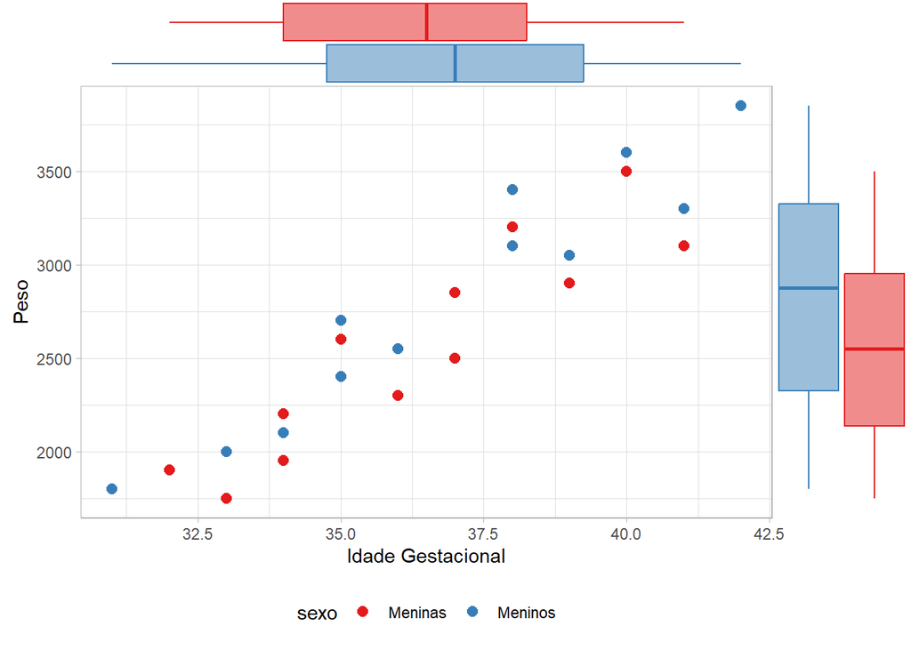

```r
library(ggExtra)

# Passo 1: Criar o gráfico base central (Gráfico de Dispersão tradicional)
p_dispersao <- ggplot(df_completo, aes(x = x, y = y, color = sexo)) +
  geom_point(size = 2.5) +
  scale_color_manual(values = c("Meninas" = "#e41a1c", "Meninos" = "#377eb8")) +
  labs(x = "Idade Gestacional", y = "Peso") +
  theme_light() +
  theme(legend.position = "bottom")

# Passo 2: Injetar as distribuições Marginais (Neste caso, os Boxplots individuais)
ggMarginal(
  p_dispersao,
  type = "boxplot",       # Formatos marginais aceitos: "boxplot", "histogram" ou "density"
  margins = "both",       # "both" insere simultaneamente no topo (X) e na direita (Y)
  groupColour = TRUE,     # Força os boxplots marginais a respeitarem as cores dos grupos
  groupFill = TRUE        # Força o preenchimento dos boxplots marginais a respeitarem as cores dos grupos
)
```

# 11 9. Ajuste Fino e Estética Profissional

O `ggplot2` vem por padrão com um fundo cinza que pode não ser ideal para relatórios formais. Podemos alterar radicalmente a estética modificando o tema global e ajustes locais de texto.

## 11.1 Temas Prontos (`theme_*`)

Experimente usar `theme_minimal()`, `theme_light()`, `theme_bw()` ou `theme_classic()`.

## 11.2 Rotacionando Eixos e Movendo a Legenda

Muitas vezes rótulos longos se atropelam no eixo X. Podemos rotacioná-los e também reposicionar a legenda para a base do gráfico usando a função genérica `theme()`.

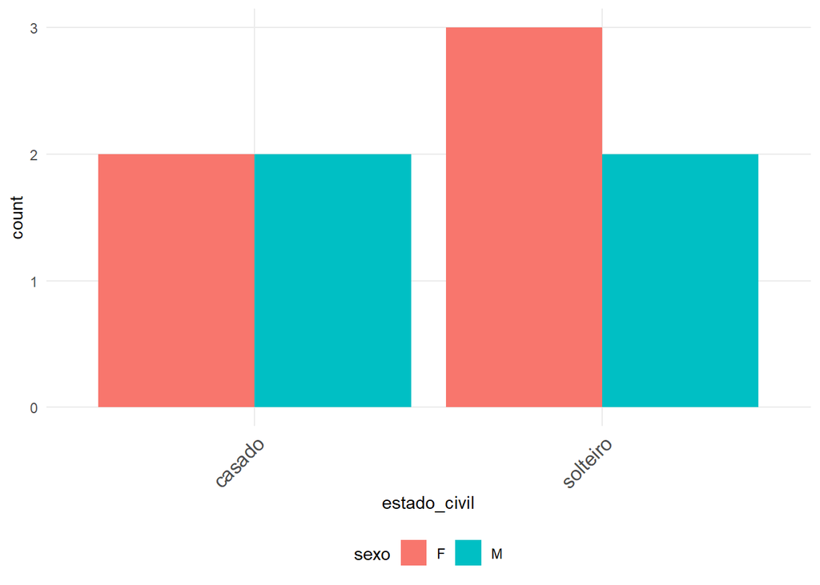

```r
ggplot(df_sociodemo, aes(x = estado_civil, fill = sexo)) +
  geom_bar(position = "dodge") +
  theme_minimal() +
  theme(
    legend.position = "bottom",
    axis.text.x = element_text(angle = 45, hjust = 1, size = 12),
    panel.grid.minor = element_blank()
  )
```

## 11.3 Formatação Avançada de Números com o pacote `scales`

Dados reais frequentemente possuem valores numéricos puros extensos ou decimais que dificultam o entendimento do leitor. Em vez de transformar as colunas do banco de dados em texto, a abordagem profissional utiliza o pacote `scales` dentro dos argumentos `labels` das escalas contínuas do ggplot.

A função `label_number()` permite inserir marcadores de milhar (ponto) e decimais (vírgula) automaticamente no padrão brasileiro.

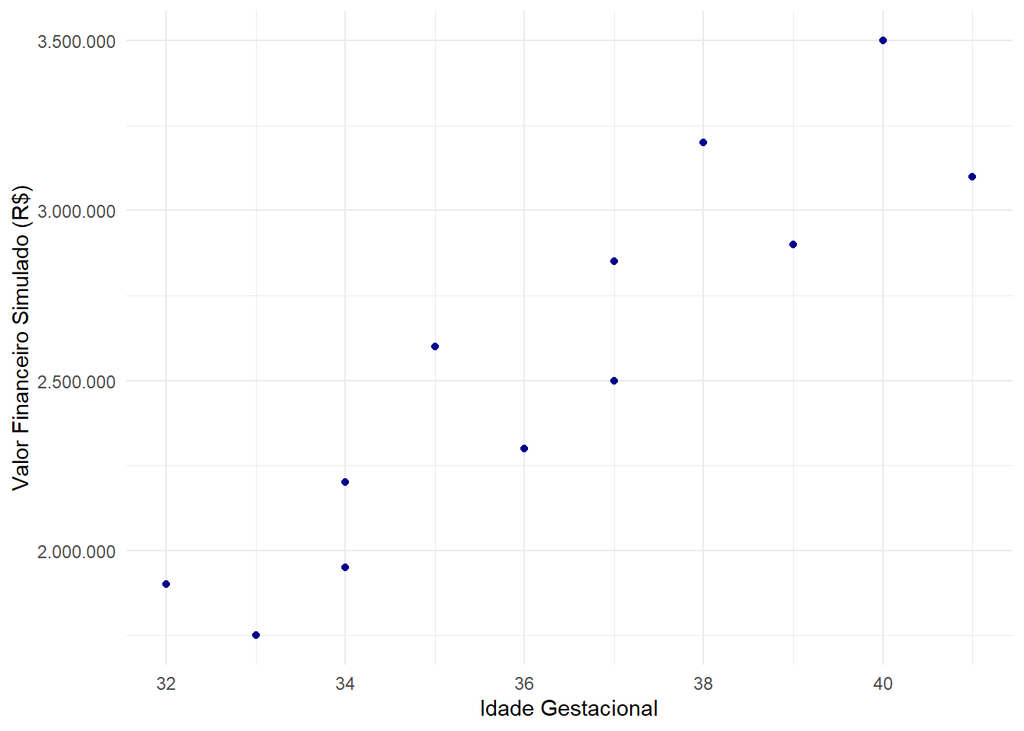

```r
# Exemplo simulando valores financeiros altos ou populações grandes no eixo Y
ggplot(df_gestacao, aes(x = x, y = y * 1000)) +
  geom_point(color = "darkblue") +
  scale_y_continuous(labels = label_number(big.mark = ".", decimal.mark = ",")) +
  labs(x = "Idade Gestacional", y = "Valor Financeiro Simulado (R$)") +
  theme_minimal()
```

## 11.4 Customizando Paletas de Cores Manuais

Para ter controle total sobre as cores dos preenchimentos (`fill`) ou pontos (`color`), usamos as funções da família `scale_*_manual()`.

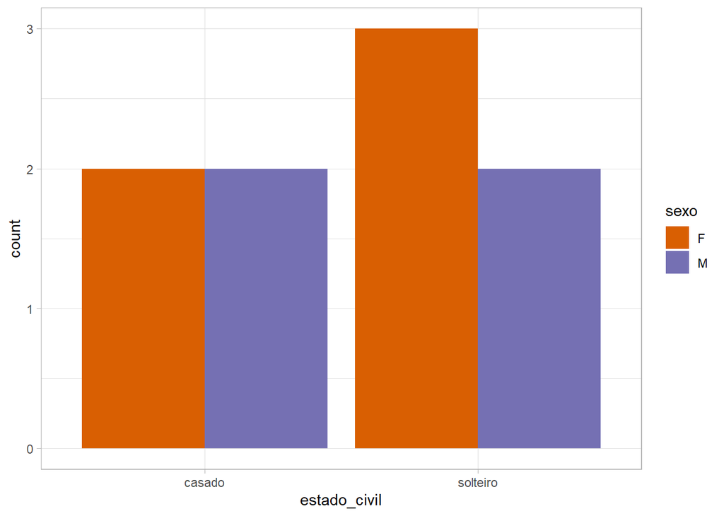

```r
ggplot(df_sociodemo, aes(x = estado_civil, fill = sexo)) +
  geom_bar(position = "dodge") +
  scale_fill_manual(values = c("F" = "#d95f02", "M" = "#7570b3")) +
  theme_light()
```

# 12 10. Guia de Resolução de Problemas (Troubleshooting)

Ao iniciar no `ggplot2`, é normal se deparar com erros de execução. Abaixo estão listadas as quatro falhas mais comuns ocorridas em laboratórios e como corrigi-las:

1. **Erro: `Could not find function "ggplot"`**
   - *Causa:* Você tentou rodar o código do gráfico sem carregar a biblioteca primeiro.
   - *Solução:* Execute `library(ggplot2)` antes de construir o gráfico.
2. **Erro de renderização: Gráfico conectado em zigue-zague confuso**
   - *Causa:* Você utilizou `geom_line()` em uma base que possui mais de uma categoria ou indivíduo e esquecer-se de especificar o subgrupo.
   - *Solução:* Adicione `group = sua_variavel_categorica` dentro da função `aes()`.
3. **Comportamento inesperado: Legenda estranha criada com o nome “red”**
   - *Causa:* Você colocou uma propriedade de cor fixa (como `"red"`) por engano **dentro** da função `aes()`. O R interpreta qualquer texto dentro de `aes()` como uma nova variável.
   - *Solução:* Retire a cor do `aes()` e coloque-a diretamente na geometria, ex: `geom_point(color = "red")`.
4. **Erro de sintaxe: Operador Pipe (`%>%` ou `|>`) conectando camadas**
   - *Causa:* Confundir a sintaxe de manipulação do pacote `dplyr` com a do `ggplot2`.
   - *Solução:* Para somar camadas visuais ao gráfico, use estritamente o operador de adição **`+`**.

# 13 10.1. Salvando Gráficos com `ggsave()`

Esqueça a necessidade de abrir e fechar dispositivos de tela manualmente. A função `ggsave()` captura automaticamente o último gráfico impresso no RStudio e o salva definindo extensões, dimensões físicas e resoluções profissionais (`dpi`).

```r
ggplot(df_gestacao, aes(x = x, y = y)) + geom_point()

# Salvando de forma direta no diretório de trabalho
ggsave("meu_grafico_final.png", width = 6, height = 4, dpi = 300)
```

# 14 11. Atividades Práticas

Um botânico realizou um experimento para analisar o impacto da **Dose de Fertilizante** (Variável `dose`, em miligramas) na **Altura Final da Planta** (Variável `altura`, em centímetros). Ele utilizou 50 mudas divididas igualmente entre duas categorias: `Especie 1` e `Especie 2`.

Prepare o banco de dados unificado executando o bloco abaixo:

```r
df_botanica <- data.frame(
  dose = c(
    74.9, 98.1, 89.3, 83.9, 66.2, 66.2, 62.3, 94.7, 84.0, 88.3, 60.8, 98.8, 93.3, 68.5, 67.3, 67.3, 72.2, 77.0, 77.3, 71.6, 65.6, 71.7, 89.7, 78.2, 85.6,
    27.9, 43.5, 37.8, 31.8, 21.8, 22.1, 22.0, 47.3, 38.2, 40.5, 20.2, 49.6, 44.2, 23.4, 22.8, 22.8, 26.1, 29.5, 29.7, 25.5, 23.2, 25.7, 41.3, 31.9, 37.1
  ),
  altura = c(
    59.8, 80.6, 74.3, 67.7, 48.4, 56.4, 54.7, 81.3, 66.4, 71.9, 43.6, 84.2, 73.0, 50.8, 57.5, 54.4, 59.5, 60.9, 57.0, 55.4, 50.7, 61.3, 64.9, 67.5, 68.0,
    24.3, 32.5, 21.0, 26.5, 13.5, 14.5, 21.3, 36.3, 26.6, 31.6, 13.5, 40.9, 34.5, 14.2, 13.0, 13.2, 21.6, 22.1, 15.1, 18.2, 19.4, 18.0, 25.5, 21.6, 26.6
  ),
  especie = factor(rep(c("Especie 1", "Especie 2"), each = 25))
)
```

Utilizando as funções do pacote `ggplot2` e suas extensões, monte os scripts para gerar as visualizações solicitadas a seguir. Salve cada gráfico como imagem usando `ggsave()`.

### 14.0.1 Exercício 1 — Gráfico de Dispersão Customizado (Apenas Espécie 1)

1. Faça o gráfico de dispersão de `altura` ($y$) versus `dose` ($x$) filtrando apenas para a Espécie 1.
2. Atribua um título principal explicativo e altere os nomes dos eixos para incluir as unidades de medida (mg e cm).
3. Adicione uma linha horizontal indicando a média da altura e uma linha vertical indicando a média da dose observada para essa espécie.
4. Insira a reta de regressão linear estimada usando a geometria correta (`method = "lm"`). Remova a banda cinza de erro padrão.
5. Modifique o visual aplicando o tema `theme_classic()`.

### 14.0.2 Exercício 2 — Mapeamento e Ajuste de Legendas

1. Utilizando a tabela completa (`df_botanica`), crie um gráfico de dispersão mapeando a variável `especie` para a propriedade de cor (`color`) e formato (`shape`) simultaneamente dentro do `aes()`.
2. Aplique o tema `theme_minimal()`.
3. Usando a função `theme()`, mova a legenda do gráfico para a posição inferior (`"bottom"`).
4. Altere manualmente as cores dos grupos utilizando a função `scale_color_manual()`, escolhendo duas cores de sua preferência.

### 14.0.3 Exercício 3 — O Poder das Facetas

1. Crie um gráfico de dispersão contendo a relação de `altura` por `dose` para toda a base.
2. Utilize a função `facet_wrap()` para separar os gráficos das duas espécies em painéis dispostos lado a lado.
3. Adicione a reta de regressão linear de forma que uma reta independente seja desenhada em cada painel automaticamente.
4. Salve a imagem final com o nome `"experimento_botanica_facetas.png"`.

### 14.0.4 Exercício 4 — Layouts Profissionais e Análise Marginal (`ggExtra` e `patchwork`)

Utilizando os novos conceitos de organização de layouts complexos, resolva os desafios abaixo para a base `df_botanica`:

1. **Análise Marginal com `ggExtra`**: Crie um gráfico de dispersão central de `altura` por `dose`. Mapeie a variável `especie` para a cor dos pontos. Em seguida, utilize a função `ggMarginal()` para adicionar **histogramas marginais preenchidos** nas bordas (tanto no topo quanto na direita), garantindo que as cores das barras sigam os grupos de espécies (`groupFill = TRUE`).
2. **Combinação Avançada com `patchwork`**: Crie dois gráficos separados para a variável `altura`:
   - Um Boxplot horizontal da altura por espécie (`ggplot(df_botanica, aes(x = altura, fill = especie)) + geom_boxplot()`).
   - Um Histograma geral da altura com 12 intervalos (`bins = 12`).
3. **Montagem Final**: Utilizando os operadores do pacote `patchwork`, empilhe verticalmente o Boxplot construído sobre o Histograma, configurando o layout para que o Boxplot ocupe 25% da altura total da imagem e o histograma ocupe os 75% restantes. Salve o resultado final com o nome `"layout_distribuicao_plantas.png"`.

### 14.0.5 Exercício 5 — Desafio de Séries Temporais e Formatação (Bônus)

O botânico mediu a altura média das plantas ao longo de 5 semanas consecutivas para ambas as espécies:

```r
df_temporal <- data.frame(
  semana = rep(1:5, times = 2),
  altura_media = c(12.5, 22.4, 35.1, 48.3, 62.1,  # Especie 1
                   10.2, 15.3, 21.4, 28.6, 35.2), # Especie 2
  especie = rep(c("Especie 1", "Especie 2"), each = 5)
)
```

**Desafio:** a) Construa um gráfico de linhas mostrando a evolução da `altura_media` ($y$) ao longo da `semana` ($x$). b) Garanta que cada espécie tenha uma linha de cor diferente. *Dica: Lembre-se de mapear o argument `group` para que o ggplot saiba como conectar os pontos corretamente.* c) Adicione uma camada de pontos (`geom_point`) sobre as lines para destacar as medições de cada semana. d) Formate o eixo Y para exibir os números acompanhados pelo sufixo ” cm” de maneira automática, utilizando a função de formatação adequada do pacote `scales` (ex: `labels = label_number(suffix = " cm")`). e) Altere o tema para `theme_minimal()`.